# GGPLOT2 features - Add vertical line to dates axis

PLR

2022-10-09

## Add a vertical geom vline to date axis

R Script to add a vertical line to a plot containing date variables on the X axis. We use geom_vline() geom in GGPLOT2 to add vertical lines to a plot.

Reference: https://stackoverflow.com/questions/5388832/how-to-get-a-vertical-geom-vline-to-an-x-axis-of-class-date

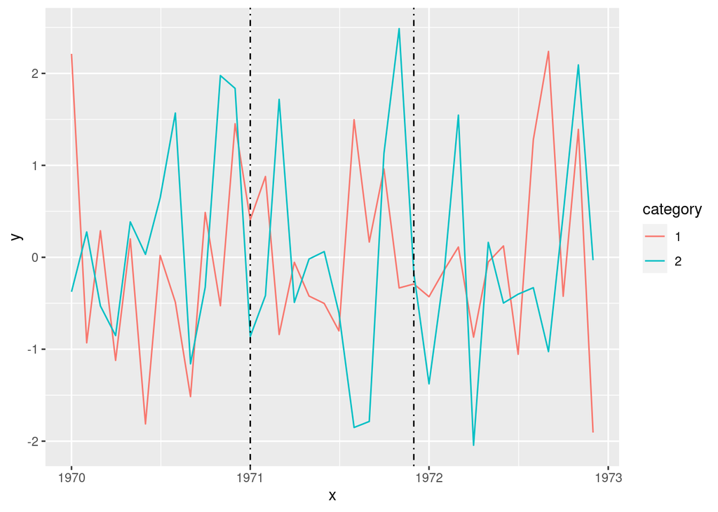

```r
library("ggplot2")

tmp <- data.frame(x=rep(seq(as.Date(0, origin="1970-01-01"),length=36, by="1 month"), 2),
                  y=rnorm(72),category=gl(2,36))

p <- ggplot(tmp, aes(x, y, colour=category)) +
     geom_line() +
     geom_vline(xintercept=as.numeric(tmp$x[c(13, 24)]),
                linetype=4, colour="black")
print(p)
```

We need to define **as.numeric** the date values on the X axis where we want the vertical X axis line to be displayed.

### Flag dates based on X axis position

We can change the parameters for date. The problem with this methos is that is difficult to match the date variable for a specific day with the X coordinates we introduce in the xintercept() function.

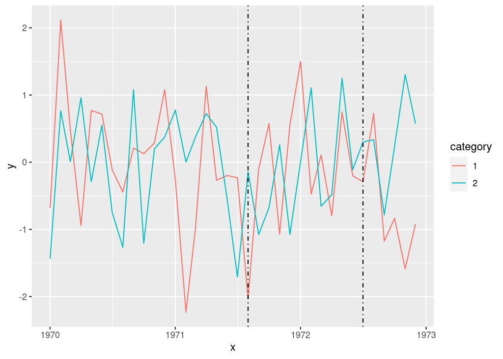

```r
library("ggplot2")

tmp <- data.frame(x=rep(seq(as.Date(0, origin="1970-01-01"),length=36, by="1 month"), 2),
                  y=rnorm(72),category=gl(2,36))

p1 <- ggplot(tmp, aes(x, y, colour=category)) +
     geom_line() +
     geom_vline(xintercept=as.numeric(tmp$x[c(20, 31)]),
                linetype=4, colour="black")
print(p1)
```

### 1. Preferred method using dates to draw geom_vline

In the same Stack Overflow post, there is a comment that sugest using ’geom_vline(xintercept = as.numeric(as.Date(“1972-01-01”)),linetype =4) as a method to draw vertical lines using specific date values

Take a look to the initial date range in the data set

```r
head(tmp)
```

```
##            x          y category
## 1 1970-01-01 -0.6815960        1
## 2 1970-02-01  2.1150702        1
## 3 1970-03-01  0.4856564        1
## 4 1970-04-01 -0.9414947        1
## 5 1970-05-01  0.7698113        1
## 6 1970-06-01  0.7163733        1
```

From the same website above, we can introduce as.Date() function within the geom_vline() statement. To draw lines on specific dates

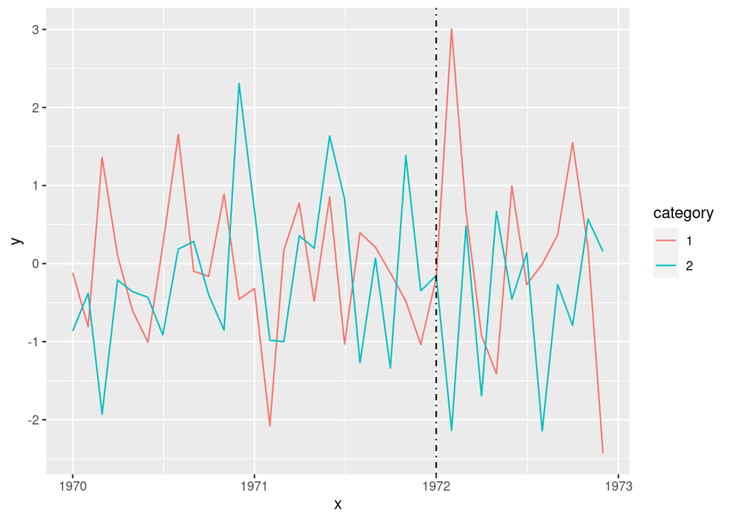

```r
library("ggplot2")

tmp <- data.frame(x=rep(seq(as.Date(0, origin="1970-01-01"),length=36, by="1 month"), 2),
                  y=rnorm(72),category=gl(2,36))

p2 <- ggplot(tmp, aes(x, y, colour=category)) +
     geom_line() +
     geom_vline(xintercept = as.numeric(as.Date("1972-01-01")), linetype=4)
print(p2)
```

### 2. Add context highlighting 1970s recession

We are going to take as an example the 1970s recession that lasted from 1973-1975 in the United Kingdom. As this is a test plot, the data is just for learning purposes.

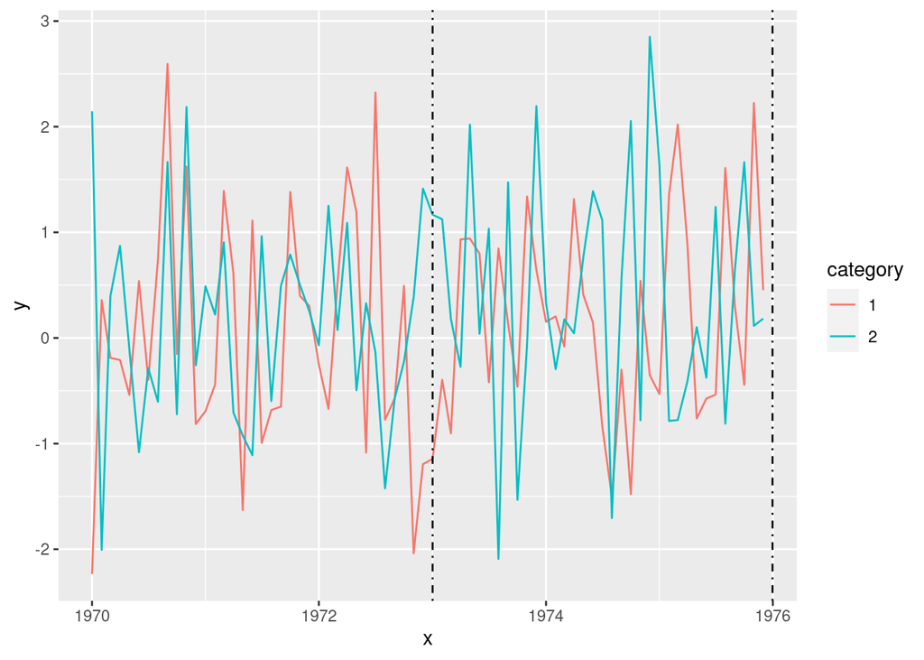

```r
library("ggplot2")

tmp <- data.frame(x=rep(seq(as.Date(0, origin="1970-01-01"),length=72, by="1 month"), 2),
                  y=rnorm(144),category=gl(2,72))

p3 <- ggplot(tmp, aes(x, y, colour=category)) +
     geom_line() +
  # Recession starts 1973
     geom_vline(xintercept = as.numeric(as.Date("1973-01-01")), linetype=4) +
  # Recession end 1975
    geom_vline(xintercept = as.numeric(as.Date("1975-12-31")), linetype=4)

print(p3)
```